# REPAIR: full influence functions, person bootstrap, and legacy stacked SEs

2026-10-30

## 1 Findings and practical implications

The full influence calculation now follows the actual REPAIR M-MOM estimator, including estimated measurement parameters, structural weights, corrections and the signed cross-stage covariance. Its implementation passes independent likelihood, frequency-perturbation, reoptimization and OLS special-case checks. **Correct variance propagation alone does not fix the difficult finite-sample inference in this screen.** Keep the method experimental; the results support retaining person-level bootstrap inference as the practical alternative in these settings, while reporting its remaining failures and bias limitations.

- Full influence inference returned **1,351 / 2,400** structural analyses. There were 1,048 refusals at singular measurement covariances and one unstable parameter derivative. Stage2 influence inference returned all 2,400.
- For the nonzero noisy-predictor effect, low-information full-influence coverage ranged from **73.2% to 83.3%** among 37–66 available intervals per profile. Bootstrap coverage ranged from **79.4% to 95.8%** among 95–98 intervals. Availability differs, so the report also supplies matched-eligible contrasts. In three profiles these favor bootstrap coverage by about 11–17 percentage points, with paired Monte Carlo intervals excluding zero; this exploratory screen is not an adjusted multiple-comparison or confirmatory study.
- In the high-reliability noisy-predictor control all methods returned 100 intervals; full influence coverage was 92%, bootstrap 91%, conditional 94%. A coverage near 95% has Monte Carlo SE about 2.2 percentage points at Nsim=100. These differences do not establish superiority.
- In balanced random-slope-outcome analyses, the focal full and stage2 variance reduce to OLS HC0. Across 1,000 balanced legacy comparisons, point estimates agreed within 5.6e-16 and stage2/legacy HC0 variances within 6.1e-8. The old helper’s HC corrections and t reference are distinct finite-sample choices; their performance must not be attributed to cross-stage propagation.
- The small/short noisy-predictor profile still had point bias about −.207 at truth .40, and bootstrap coverage only 79.4%. None of these SE methods removes that bias. Bootstrap availability or smaller analytic SEs do not establish calibrated inference.

## 2 Design, estimands, and comparability

This is a **paired exploratory extension of the existing robust-refit screen**, reusing 600 measurement datasets: six profiles × 100 outer replications. Each dataset supplies two structural designs (arms A/B), each with truths 0 and .40. These are 2,400 structural analyses, not 2,400 independent measurement datasets. Streams and native fitting decisions are shared across the comparisons. Main bootstrap B=499; the fixed first three datasets/profile extend to B=1,999. Excluded development/timing data use replication 801. The protocol in design.md was frozen before inspecting full-grid influence performance.

| profile | n | small | large | reliability | rho | tau | sigma | achieved_reliability | partial_reliability | reliability_small | reliability_large |
| --- | --- | --- | --- | --- | --- | --- | --- | --- | --- | --- | --- |
| low_balanced | 50 | 10 | 10 | 0.25 | 0.5 | 0.9 | 5.179 | 0.25 | 0.162 | 0.25 | 0.25 |
| low_negative | 50 | 10 | 10 | 0.25 | -0.5 | 0.9 | 5.179 | 0.25 | 0.162 | 0.25 | 0.25 |
| small_short | 30 | 3 | 3 | 0.25 | 0.5 | 0.9 | 2.504 | 0.25 | 0.156 | 0.25 | 0.25 |
| low_larger | 100 | 10 | 10 | 0.25 | 0.5 | 0.9 | 5.179 | 0.25 | 0.162 | 0.25 | 0.25 |
| high_control | 100 | 10 | 10 | 0.80 | 0.5 | 0.9 | 1.395 | 0.80 | 0.704 | 0.80 | 0.80 |
| low_unequal | 50 | 3 | 17 | 0.25 | 0.5 | 0.9 | 4.694 | 0.25 | 0.170 | 0.09 | 0.41 |

The Gaussian measurement model is Y=.5*time+b0+b1*time+eps. Within-person time is centered and sample-SD standardized; SD(b0)=SD(b1)=.9 and their correlation is +.5 or −.5. Residual SD calibrates full-posterior slope reliability (.25 except .8 in the control). Unequal information allocates half the people to 3 and half to 17 observations, independently of latent effects/errors. The additional stratified comparator preserves these counts; it is a study comparator, not a new package strata API.

**Arm A: noisy predictors.** Keep the previous structural outcome Z=1.5+.4*b0+(gamma/.9)*b1+eta with Var(Z)=1 and Gaussian homoskedastic eta. Fit both recovered intercept and slope as noisy predictors. Report the focal slope coefficient/SE/endpoints multiplied by the population SD .9. The old OLS-outcome stacked helper does not implement this estimator and is deliberately absent from arm A.

**Arm B: random-slope outcome.** Extract the shared independent standard-normal z from the original null structural outcome and construct x_gamma=gamma*b1/.9+sqrt(1-gamma^2)*z. Joint normality gives E[b1|x_gamma]=.9*gamma*x_gamma. Fit re(time)~x_gamma and divide the focal coefficient/SE/endpoints by .9. The old stacked helper is evaluated unchanged, using an ML measurement fit and OLS structural regression, HC0–HC3 and its original t_(N−2) reference. REPAIR retains REML and uses normal Wald intervals for its influence calculations. In balanced schedules common fixed-slope centering cancels and M-MOM’s weights are constant, yielding an exact OLS slope anchor. Under unequal schedules M-MOM estimates precision weights whereas the old helper uses unweighted OLS: the same population target, different estimators. Its HC1 scaling uses the total stacked parameter count, as in the original code. The legacy helper returns finite results even at some singular native fits; its original behavior is preserved, rather than applying the new IF boundary gate.

The legacy helper is sourced from the research repository’s R/stacked_sandwich_helpers.R and R/derivative_backends.R. It is a simulation comparator, not a new exported package inference method. The research code is not copied into the MIT package. Its analytic backend computes an observed score Hessian; a misleading expected-information label does not change the executed comparator. Source hashes and fitting criteria are archived.

## 3 What the new covariance estimates

For fixed total person frequency N, T(f,psi) denotes the canonical finite-sample structural estimator. U_i=N*dT/df along the centered person-frequency direction. The measurement influence is H^-1*S_i*, with H minus the average score Jacobian and S_i* the centered frequency derivative of the native fitting score. D=dT/dpsi. The full person influence is U_i+D*IF_psi,i. Its empirical outer product divided by N^2 includes stage2, measurement and both signed cross-stage terms.

Measurement scores are analytic Gaussian scores; their Jacobian and the entire structural sensitivity are numerically differentiated, with central/half-step, one-sided and active-branch checks. For REML both the global fixed-design information determinant and its person-frequency derivative are retained. ML scores at a REML fit would propagate a different procedure. There are no hidden HC corrections, pseudoinverses or ridges. All original point estimates and ordinary conditional SEs remain unchanged.

Stage2 differentiates the full structural estimator with measurement quantities fixed. It still re-estimates structural variance, weights and corrections and therefore differs from the ordinary model-based conditional M-MOM SE. Stable local regularization/floor branches are allowed and reported; neither numerical stability nor a local derivative establishes uniform validity near a boundary. Many noisy-predictor analyses occupy the forced-zero residual-variance branch. The bootstrap can cross branches and captures a different finite-sample shape; the poor local Wald coverage here cannot be resolved merely by adding a positive measurement variance term or assuming that every full SE should increase.

## 4 Availability

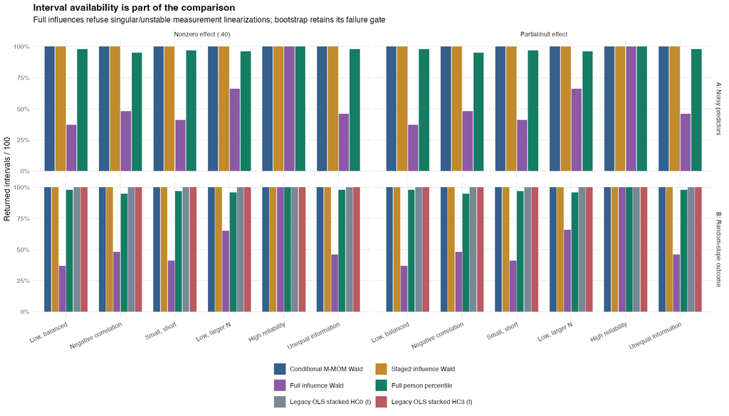

| measurement_singular | full | Freq |
| --- | --- | --- |
| FALSE | FALSE | 1 |
| TRUE | FALSE | 1048 |
| FALSE | TRUE | 1351 |

All 1,048 singular-model refusals are intentional. The one other refusal is arm B, low_larger, replication 68, gamma=.40: an unstable/branch-sensitive measurement-parameter derivative at coordinate 6 (log residual SD). The original stage2 result remains available. There were no driver, replay-reconstruction or public-API errors. We retained the prespecified step/tolerance rather than tuning them to maximize availability after viewing coverage.

Coverage and zero exclusion use **only available intervals**. The CSVs also report interval-and-cover/detect per all 100 planned datasets. Missing intervals are not valid non-rejections. Conditioning on availability selects a subset and can change the apparent distribution; compare common eligible datasets too.

## 5 Arm A: noisy predictors

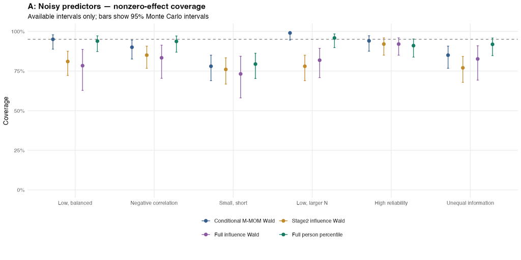

Nonzero effect: zero exclusion is detection, not a type-I error rate.

| Profile | Method | Intervals / 100 | Coverage | Zero exclusion | Median width |
| --- | --- | --- | --- | --- | --- |
| low_balanced | Conditional M-MOM Wald | 100 | 0.950 | 0.020 | 1.529 |
| low_balanced | Stage2 influence Wald | 100 | 0.810 | 0.260 | 1.005 |
| low_balanced | Full influence Wald | 37 | 0.784 | 0.189 | 0.814 |
| low_balanced | Full person percentile | 98 | 0.939 | 0.224 | 0.884 |
| low_negative | Conditional M-MOM Wald | 100 | 0.900 | 0.010 | 1.543 |
| low_negative | Stage2 influence Wald | 100 | 0.850 | 0.240 | 0.958 |
| low_negative | Full influence Wald | 48 | 0.833 | 0.146 | 0.926 |
| low_negative | Full person percentile | 95 | 0.937 | 0.084 | 1.041 |
| small_short | Conditional M-MOM Wald | 100 | 0.780 | 0.000 | 1.253 |
| small_short | Stage2 influence Wald | 100 | 0.760 | 0.290 | 0.755 |
| small_short | Full influence Wald | 41 | 0.732 | 0.268 | 0.697 |
| small_short | Full person percentile | 97 | 0.794 | 0.155 | 0.762 |
| low_larger | Conditional M-MOM Wald | 100 | 0.990 | 0.050 | 2.302 |
| low_larger | Stage2 influence Wald | 100 | 0.780 | 0.310 | 1.165 |
| low_larger | Full influence Wald | 66 | 0.818 | 0.333 | 1.141 |
| low_larger | Full person percentile | 96 | 0.958 | 0.240 | 1.165 |
| high_control | Conditional M-MOM Wald | 100 | 0.940 | 0.950 | 0.443 |
| high_control | Stage2 influence Wald | 100 | 0.920 | 0.940 | 0.439 |
| high_control | Full influence Wald | 100 | 0.920 | 0.940 | 0.438 |
| high_control | Full person percentile | 100 | 0.910 | 0.940 | 0.475 |
| low_unequal | Conditional M-MOM Wald | 100 | 0.850 | 0.230 | 1.074 |
| low_unequal | Stage2 influence Wald | 100 | 0.770 | 0.230 | 1.003 |
| low_unequal | Full influence Wald | 46 | 0.826 | 0.109 | 1.037 |
| low_unequal | Full person percentile | 98 | 0.918 | 0.163 | 0.899 |

Null focal effect, conditional on the other noisy random coefficient:

| Profile | Method | Intervals / 100 | Coverage | Zero exclusion | Median width |
| --- | --- | --- | --- | --- | --- |
| low_balanced | Conditional M-MOM Wald | 100 | 1.000 | 0.000 | 1.575 |
| low_balanced | Stage2 influence Wald | 100 | 0.870 | 0.130 | 1.052 |
| low_balanced | Full influence Wald | 37 | 0.946 | 0.054 | 0.929 |
| low_balanced | Full person percentile | 98 | 0.929 | 0.071 | 1.012 |
| low_negative | Conditional M-MOM Wald | 100 | 0.990 | 0.010 | 1.482 |
| low_negative | Stage2 influence Wald | 100 | 0.910 | 0.090 | 1.051 |
| low_negative | Full influence Wald | 48 | 0.979 | 0.021 | 0.988 |
| low_negative | Full person percentile | 95 | 0.979 | 0.021 | 1.034 |
| small_short | Conditional M-MOM Wald | 100 | 0.990 | 0.010 | 1.089 |
| small_short | Stage2 influence Wald | 100 | 0.820 | 0.180 | 0.844 |
| small_short | Full influence Wald | 41 | 0.927 | 0.073 | 0.826 |
| small_short | Full person percentile | 97 | 0.938 | 0.062 | 0.841 |
| low_larger | Conditional M-MOM Wald | 100 | 0.990 | 0.010 | 2.253 |
| low_larger | Stage2 influence Wald | 100 | 0.860 | 0.140 | 1.251 |
| low_larger | Full influence Wald | 66 | 0.909 | 0.091 | 1.156 |
| low_larger | Full person percentile | 96 | 0.958 | 0.042 | 1.392 |
| high_control | Conditional M-MOM Wald | 100 | 0.930 | 0.070 | 0.526 |
| high_control | Stage2 influence Wald | 100 | 0.920 | 0.080 | 0.520 |
| high_control | Full influence Wald | 100 | 0.920 | 0.080 | 0.519 |
| high_control | Full person percentile | 100 | 0.930 | 0.070 | 0.554 |
| low_unequal | Conditional M-MOM Wald | 100 | 0.850 | 0.150 | 0.973 |
| low_unequal | Stage2 influence Wald | 100 | 0.880 | 0.120 | 0.996 |
| low_unequal | Full influence Wald | 46 | 0.935 | 0.065 | 0.875 |
| low_unequal | Full person percentile | 98 | 0.980 | 0.020 | 0.999 |

Full influence versus full bootstrap, **coverage on common available datasets**:

| profile | n | difference | mc_low | mc_high | a_only | b_only |
| --- | --- | --- | --- | --- | --- | --- |
| low_balanced | 36 | -0.167 | -0.290 | -0.043 | 0 | 6 |
| low_negative | 45 | -0.089 | -0.194 | 0.016 | 1 | 5 |
| small_short | 39 | -0.026 | -0.139 | 0.088 | 2 | 3 |
| low_larger | 62 | -0.113 | -0.192 | -0.033 | 0 | 7 |
| high_control | 100 | 0.010 | -0.010 | 0.030 | 1 | 0 |
| low_unequal | 46 | -0.109 | -0.200 | -0.018 | 0 | 5 |

Differences are IF minus bootstrap; bounds are normal paired Monte Carlo bounds, based on per-dataset decision differences. Zero discordance yields no asserted equivalence interval. All pairwise tables, including full vs conditional and stage2, are retained. Per-method point bias, empirical SD, eligible bias/SD and SE calibration appear in performance.csv. Conditional coverage can look high because intervals are wide; the methods share the same original point estimates.

## 6 Arm B: recovered random-slope outcome

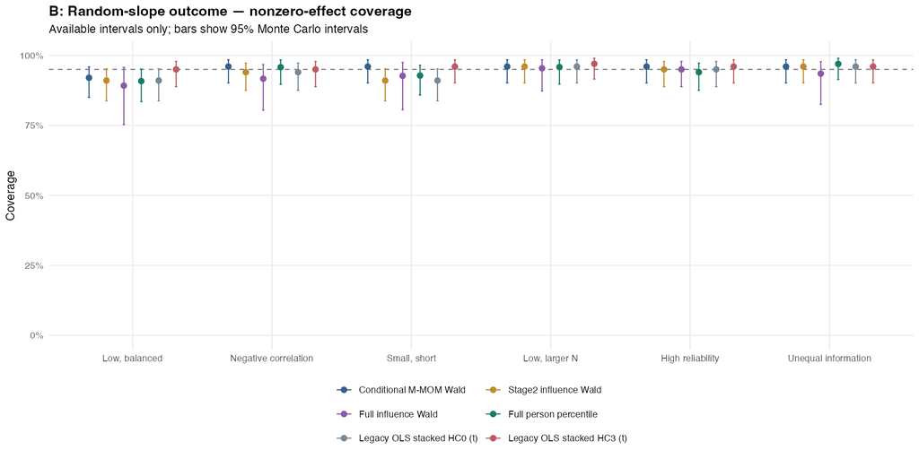

| Profile | Method | Intervals / 100 | Coverage | Zero exclusion | Median width |
| --- | --- | --- | --- | --- | --- |
| low_balanced | Conditional M-MOM Wald | 100 | 0.920 | 0.300 | 1.201 |
| low_balanced | Stage2 influence Wald | 100 | 0.910 | 0.320 | 1.140 |
| low_balanced | Full influence Wald | 37 | 0.892 | 0.405 | 1.195 |
| low_balanced | Full person percentile | 98 | 0.908 | 0.296 | 1.158 |
| low_balanced | Legacy OLS stacked HC0 (t) | 100 | 0.910 | 0.300 | 1.169 |
| low_balanced | Legacy OLS stacked HC3 (t) | 100 | 0.950 | 0.270 | 1.243 |
| low_negative | Conditional M-MOM Wald | 100 | 0.960 | 0.270 | 1.184 |
| low_negative | Stage2 influence Wald | 100 | 0.940 | 0.320 | 1.132 |
| low_negative | Full influence Wald | 48 | 0.917 | 0.292 | 1.224 |
| low_negative | Full person percentile | 95 | 0.958 | 0.253 | 1.170 |
| low_negative | Legacy OLS stacked HC0 (t) | 100 | 0.940 | 0.310 | 1.162 |
| low_negative | Legacy OLS stacked HC3 (t) | 100 | 0.950 | 0.230 | 1.248 |
| small_short | Conditional M-MOM Wald | 100 | 0.960 | 0.130 | 1.646 |
| small_short | Stage2 influence Wald | 100 | 0.910 | 0.190 | 1.475 |
| small_short | Full influence Wald | 41 | 0.927 | 0.171 | 1.615 |
| small_short | Full person percentile | 97 | 0.928 | 0.186 | 1.578 |
| small_short | Legacy OLS stacked HC0 (t) | 100 | 0.910 | 0.180 | 1.542 |
| small_short | Legacy OLS stacked HC3 (t) | 100 | 0.960 | 0.140 | 1.739 |
| low_larger | Conditional M-MOM Wald | 100 | 0.960 | 0.480 | 0.826 |
| low_larger | Stage2 influence Wald | 100 | 0.960 | 0.510 | 0.815 |
| low_larger | Full influence Wald | 65 | 0.954 | 0.523 | 0.825 |
| low_larger | Full person percentile | 96 | 0.958 | 0.510 | 0.824 |
| low_larger | Legacy OLS stacked HC0 (t) | 100 | 0.960 | 0.490 | 0.825 |
| low_larger | Legacy OLS stacked HC3 (t) | 100 | 0.970 | 0.430 | 0.861 |
| high_control | Conditional M-MOM Wald | 100 | 0.960 | 0.970 | 0.414 |
| high_control | Stage2 influence Wald | 100 | 0.950 | 0.980 | 0.396 |
| high_control | Full influence Wald | 100 | 0.950 | 0.980 | 0.396 |
| high_control | Full person percentile | 100 | 0.940 | 0.970 | 0.405 |
| high_control | Legacy OLS stacked HC0 (t) | 100 | 0.950 | 0.980 | 0.401 |
| high_control | Legacy OLS stacked HC3 (t) | 100 | 0.960 | 0.960 | 0.418 |
| low_unequal | Conditional M-MOM Wald | 100 | 0.960 | 0.240 | 1.251 |
| low_unequal | Stage2 influence Wald | 100 | 0.960 | 0.250 | 1.178 |
| low_unequal | Full influence Wald | 46 | 0.935 | 0.239 | 1.272 |
| low_unequal | Full person percentile | 98 | 0.969 | 0.235 | 1.264 |
| low_unequal | Legacy OLS stacked HC0 (t) | 100 | 0.960 | 0.180 | 1.581 |
| low_unequal | Legacy OLS stacked HC3 (t) | 100 | 0.960 | 0.130 | 1.702 |

| Profile | Method | Intervals / 100 | Coverage | Zero exclusion | Median width |
| --- | --- | --- | --- | --- | --- |
| low_balanced | Conditional M-MOM Wald | 100 | 0.930 | 0.070 | 1.220 |
| low_balanced | Stage2 influence Wald | 100 | 0.910 | 0.090 | 1.182 |
| low_balanced | Full influence Wald | 37 | 0.865 | 0.135 | 1.234 |
| low_balanced | Full person percentile | 98 | 0.949 | 0.051 | 1.203 |
| low_balanced | Legacy OLS stacked HC0 (t) | 100 | 0.930 | 0.070 | 1.213 |
| low_balanced | Legacy OLS stacked HC3 (t) | 100 | 0.950 | 0.050 | 1.302 |
| low_negative | Conditional M-MOM Wald | 100 | 0.930 | 0.070 | 1.216 |
| low_negative | Stage2 influence Wald | 100 | 0.930 | 0.070 | 1.180 |
| low_negative | Full influence Wald | 48 | 0.875 | 0.125 | 1.281 |
| low_negative | Full person percentile | 95 | 0.937 | 0.063 | 1.203 |
| low_negative | Legacy OLS stacked HC0 (t) | 100 | 0.930 | 0.070 | 1.211 |
| low_negative | Legacy OLS stacked HC3 (t) | 100 | 0.960 | 0.040 | 1.305 |
| small_short | Conditional M-MOM Wald | 100 | 0.950 | 0.050 | 1.682 |
| small_short | Stage2 influence Wald | 100 | 0.930 | 0.070 | 1.525 |
| small_short | Full influence Wald | 41 | 0.927 | 0.073 | 1.684 |
| small_short | Full person percentile | 97 | 0.948 | 0.052 | 1.634 |
| small_short | Legacy OLS stacked HC0 (t) | 100 | 0.940 | 0.060 | 1.593 |
| small_short | Legacy OLS stacked HC3 (t) | 100 | 0.980 | 0.020 | 1.825 |
| low_larger | Conditional M-MOM Wald | 100 | 0.980 | 0.020 | 0.848 |
| low_larger | Stage2 influence Wald | 100 | 0.970 | 0.030 | 0.834 |
| low_larger | Full influence Wald | 66 | 0.955 | 0.045 | 0.832 |
| low_larger | Full person percentile | 96 | 0.969 | 0.031 | 0.842 |
| low_larger | Legacy OLS stacked HC0 (t) | 100 | 0.980 | 0.020 | 0.845 |
| low_larger | Legacy OLS stacked HC3 (t) | 100 | 0.990 | 0.010 | 0.875 |
| high_control | Conditional M-MOM Wald | 100 | 0.920 | 0.080 | 0.443 |
| high_control | Stage2 influence Wald | 100 | 0.930 | 0.070 | 0.432 |
| high_control | Full influence Wald | 100 | 0.930 | 0.070 | 0.432 |
| high_control | Full person percentile | 100 | 0.930 | 0.070 | 0.435 |
| high_control | Legacy OLS stacked HC0 (t) | 100 | 0.930 | 0.070 | 0.438 |
| high_control | Legacy OLS stacked HC3 (t) | 100 | 0.940 | 0.060 | 0.456 |
| low_unequal | Conditional M-MOM Wald | 100 | 0.940 | 0.060 | 1.263 |
| low_unequal | Stage2 influence Wald | 100 | 0.930 | 0.070 | 1.167 |
| low_unequal | Full influence Wald | 46 | 0.957 | 0.043 | 1.269 |
| low_unequal | Full person percentile | 98 | 0.939 | 0.061 | 1.214 |
| low_unequal | Legacy OLS stacked HC0 (t) | 100 | 0.950 | 0.050 | 1.630 |
| low_unequal | Legacy OLS stacked HC3 (t) | 100 | 0.960 | 0.040 | 1.749 |

HC3/t coverage was 95–97% across these nonzero-effect profiles and all 100 legacy intervals/profile were finite. That is useful exploratory finite-sample evidence for this **OLS-outcome** comparator; it is not validation for noisy-predictor M-MOM and does not justify replacing REPAIR’s SE with the old helper. The unequal-design legacy width is larger partly because the point estimator is unweighted OLS. Separately archived normal-critical legacy diagnostics isolate the t reference from covariance changes. No claim of general HC3 superiority follows from 100 reused replications/profile.

## 7 Covariance decomposition and numerical sensitivity

Medians over available full results, pooling the two truths:

| profile | arm | full_to_stage2 | measurement_fraction | cross_fraction |
| --- | --- | --- | --- | --- |
| high_control | outcome | 1.00000 | 0.00000 | 0.00000 |
| low_balanced | outcome | 1.00000 | 0.00000 | 0.00000 |
| low_larger | outcome | 1.00000 | 0.00000 | 0.00000 |
| low_negative | outcome | 1.00000 | 0.00000 | 0.00000 |
| low_unequal | outcome | 1.00000 | 0.00053 | 0.00000 |
| small_short | outcome | 1.00000 | 0.00000 | 0.00000 |
| high_control | predictor | 1.00069 | 0.00090 | 0.00016 |
| low_balanced | predictor | 1.00559 | 0.00921 | 0.00027 |
| low_larger | predictor | 1.01736 | 0.01893 | 0.00224 |
| low_negative | predictor | 1.01718 | 0.01206 | 0.00098 |
| low_unequal | predictor | 0.99873 | 0.00811 | -0.00918 |
| small_short | predictor | 1.07852 | 0.07014 | 0.00984 |

In balanced arm B the focal measurement sensitivity cancels numerically; full and stage2 are the same HC0 variance. In arm A the full/stage2 variance ratio ranges roughly .79–3.62 across available analyses, so propagation can increase or decrease uncertainty. The signed cross term is essential even when median changes are modest. Per-dataset contributions, not just medians, are archived.

On the fixed first three datasets/profile (72 arm/effect checks), halving the derivative step changed no availability decisions. Maximum matched relative covariance changes were 1.35e-7 (full) and 1.19e-7 (stage2). This subset does not establish stability of every refused full-grid derivative.

Across the 156 fixed-subset bootstrap comparisons (arms, truths and methods), all B499 and B1999 intervals were available; one coverage decision changed from uncovered to covered, none in the reverse direction. Full-person median sums of absolute lower/upper endpoint changes were .0293 in arm A and .0421 in arm B. The B499 arrays are exact prefixes of the B1999 arrays. This small tail check is not a high-precision coverage study.

## 8 Bootstrap reuse and validation

Arm A retains the exact previous robust native-refit bootstrap intervals and draw maps. Arm B reuses those actual native optimizations, their convergence decisions, person draws and refitted residual SDs. Every structural estimator is recomputed per draw. Common measurement fixed-effect centering cancels from the focal slope in this design, allowing cached focal computation; **intercept bootstrap inference is not reconstructed or claimed**. Both full and frozen measurement comparisons use the original complete-vector/failure gate, with no deletion, replacement or silent acceptance of failed draws.

The first two datasets/profile, both arm-B outcomes, were checked against 24 complete public repair_bootstrap() calls at B99 (2,376 attempts). Draws, complete-vector eligibility and focal estimates agreed, maximum focal error 6.66e-16. Identity repair_refit() checks also passed. Additional independent validation recomputes coverage and zero exclusion from all 17,200 endpoints, checks centering/ID alignment and covariance sums, OLS anchors, B prefixes and frozen source/library/reference hashes.

```
PASS 600 main and 18 sensitivity comparison checkpoints, no driver/public-API errors.
PASS frozen analysis/comparator/library hashes and all original native-bootstrap file hashes.
PASS 172 method/profile/arm/effect summaries independently recomputed from 17,200 interval endpoints.
PASS unavailable intervals remain NA; not counted as valid non-rejections.
PASS all original noisy-predictor bootstrap intervals and person draws reproduced.
PASS 24 complete public outcome-bootstrap calls / 2376 attempts; maximum focal coefficient error 6.66e-16.
PASS 1351 full / 2400 stage2 influence results; covariance decomposition max relative error 1.45e-16.
PASS centered, correctly aligned person influences; maximum stage2 mean 1.12e-15.
PASS 1000 balanced OLS comparisons; max point gap 5.55e-16 / IF-HC0 variance gap 6.09e-08.
PASS B499 prefixes of B1999 outcome bootstraps: draws, finite-vector decisions, focal estimates and frozen estimates.
Derivative-step sensitivity: full availability changes 0, stage2 changes 0, max matched full relative covariance change 1.35e-07 / stage2 1.19e-07.
```

## 9 Reproduction and limits

The frozen numerical baseline is repair commit 558bdcead1c15cedd1e332aed6f01e86d49f3721, built on robust-refit head 7770874. Later scope guards reject sample-wide formula/weight recipes; this study’s pointwise time models are unchanged. Final package checks separately validate that guarded implementation against a fixed subset of recorded results. The full study archive is local to blup_unshrinking under vig_hallquist_2026/analysis/repair_bootstrap_pilot/influence_comparison; README.md records commands, libraries, source dependencies and retained checkpoints. The PR’s dev/influence-simulation bundle permits endpoint-based verification without a simulation rerun or private research code. It does not claim to contain all native bootstrap histories.

This screen covers Gaussian iid errors, six fixed schedules/reliabilities and two particular structural designs. It does not validate general heteroskedastic measurement models, informative missingness, shared nuisance effects, nlme, multiple measurement models, arbitrary adaptive transformations or nominal coverage under all boundary sequences. The full sandwich is a coherent new inference tool and diagnostic; these results argue against presenting it as a universal replacement for bootstrap or ordinary conditional inference.